# Week 2&3 Intro to Personal Website and HTML

## Week 2&3: Intro to Personal Website and HTML

&nbsp &nbsp

### 1. Create a Repo in GitHub

#### 1.1 Create a new repo in GitHub

1. Createa repo which name should be *username*.github.io, where username is your username (or organization name) on GitHub.

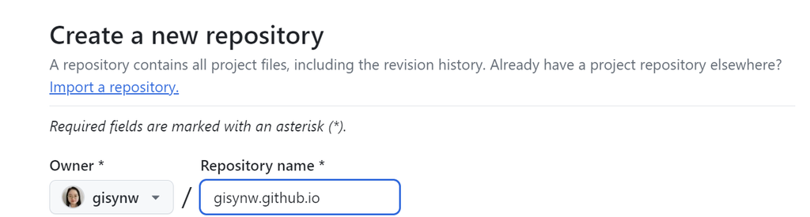

2. Select 'Public'
3. Select 'Add README file'

### 2. Check url of your personal website

1. Go to Seting of your repo
2. Go to Pages on the left side bar
3. Check the url of your personal website (The url does not generate immediately, you can check progress in action)

[figure not shown]

### 3. Clone your repo to local computer

```
git clone <url>
```

### 4. HTML page

#### 4.1 What is html?

- Hyper Text Markup Language
- It is used for creating web pages
- Describes the structure of a web page
- Consists of a series of elements

#### 4.2 HTML Page Structure

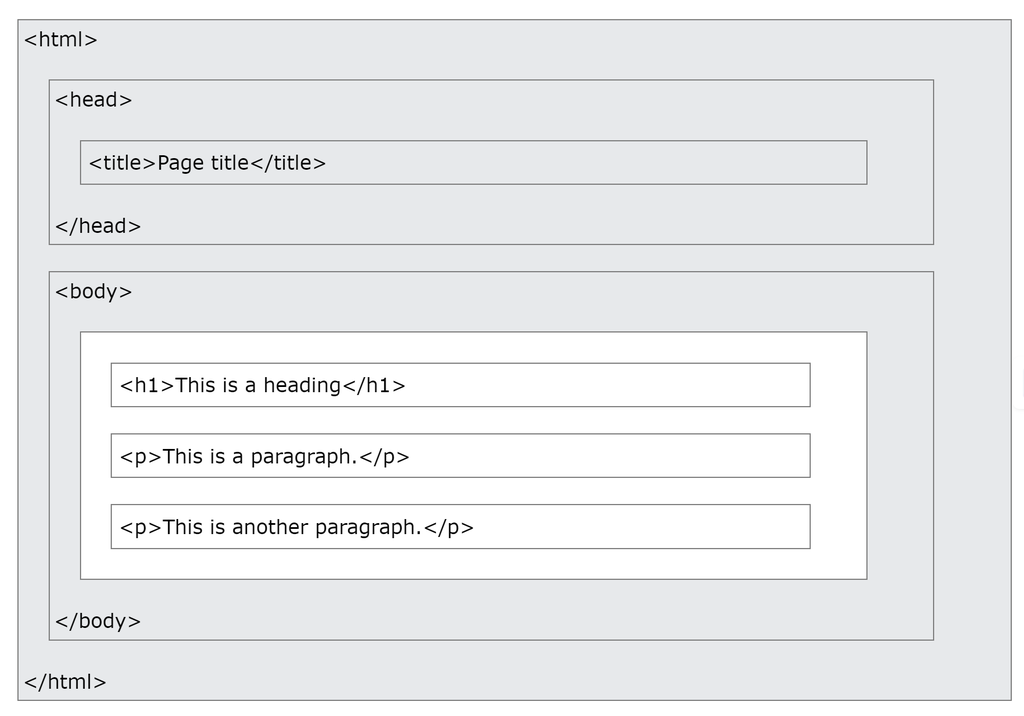

[Source](https://www.w3schools.com/html/html_intro.asp)

#### 4.3 What is an HTML element?

An HTML element is contained from start tag, and an end tag

```
<tagname> Content goes here ... </tagname>
```

`<html> Content </html>`

`<head> Content </head>`

`<body> Content </body>`

#### 4.4 The type Declaration

The `<!DOCTYPE>` declaration represents the document type, and helps browsers to display web pages correctly.

```
<!DOCTYPE html>
```

## Install Extension in VS Code

HTML Boilerplate

Liver Server

### Exercise 1: Create a html and construct the basic structure

1. Create html file in VS Code

The html file with name 'index.html' is recongizaed by GitHub as your personal website

2. Open html in VS Code

Beofre you edit html in VS code, install severall extensions to power your VS Code

Search extension from the left side panel:

- Live Server: Launch local server
- HTML Boilerplate: help on html editing
3. type **html** and select **html5:boilerplate**
4. Understand the basic structure of html

### 5 head element

#### 5.1 meta element

- `<meta charset = 'UTF-8'>`: Specifies the character encoding for the HTML document
- `<meta name="viewport" content="width=device-width, initial-scale=1.0">`
  - **width=device-width**: sets the width of the page to follow the screen-width of the device
  - **initial-scale=1.0**: the initial zoom level when the page is first loaded by the browser

#### 5.2 title element

- `<title>Personal Website</title>`

### 6. What inside the body element?

#### 6.1 header

- `<header> Content </header>`
- For introductory content or a set of navigation links

#### 6.2 heading

- `<h1>Heading 1</h1>`
- `<h5>Heading 5</h5>`

#### 6.3 paragraph

- `<p>Heading 1</p>`

#### 6.4 Comment

`<!-- Below is Introduction section -->`

Shortcut for inserting comments:

- Windows/Linux: Ctrl + /
- Mac: Cmd + /

### Exercise 2: Add the header,heading and paragraph

1. Add header
2. Add heading
3. Add paragraph

### 7. HTML Attributes

Attributes provide additional information about elements

Attributes are always specified in the start tag

#### 7.1 Style

The `stype` attribute is used to change color, font, size and more

- Format: `<tagname style="property:value;">`
- background-color
- Text-color
- Fonts

Examples:

`<h1 style="font-size:60px;">Heading 1</h1>`

`<p style="font-size:60px;">Such a good day</p>`

`<h1 style="color:blue;">This is a heading</h1>`

#### 7.2 Text formatting

There are several elements for defining text with a special meaning

`<p><strong>My major is GIS</strong></p>`

- `<b>` - Bold text
- `<strong>` - Important text
- `<i>` - Italic text
- `<em>` - Emphasized text
- `<mark>` - Marked text
- `<small>` - Smaller text
- `<del>` - Deleted text
- `<ins>` - Inserted text
- `<sub>` - Subscript text
- `<sup>` - Superscript text

### Exercise 3: Edit your text using style and Text formatting

1. Using style
2. Using Text formatting

### 8. HTML Attributes: Image

#### 8.1 Image

Specifies the path the image, width and height of the image (in pixels), alternate text for an image and tooltip for the text or image

`<img src="img_university.jpg" width="300" height="200" alt = 'Clark'>`

You can store image in Github and use the relative path (without the "https://www part) as the link

#### 8.2 Background image

##### Image on a HTML element

`<p style="background-image: url('Images/clark.jpg')">Clark University is a private research <br> university in Worcester, Massachusetts. Founded in 1887 <br> with a large endowment from its namesake Jonas Gilman <br> Clark, a prominent businessman, Clark was one of the first <br> modern research universities in the United States.</p>`

### 9. HTML Attributes: Hyperlink

#### 9.1 Hyperlink

- Use words as a link

`<a href="https://www.clarku.edu/" target ="_top">Clark University</a>`

`target` Specify where to open the linked document _self: Default. Open in the same window _blank: Open in a new window _parent: Open in the parent frame _top: Open in the full body of the window

- Use an image as a link

`<a href="https://www.clarku.edu/" target ="_black"><img src="Images\clark.jpg" alt="clark"> </a>`

- Link to an Email Address

`<a href="mailto:someone@example.com">Send email</a>`

### Exercise 4: Add image and link

1. Add image
2. Add link

### 10. Linking to a Bookmark

#### 10.1 Bookmark for header

It is created using the `<a>` tag with an `<id>` attribute to connect a section and nagavitation title

First, we create a bookmark for a element using `id` attribute

`<h1 id = "Pro">Projects</h1>`

Second, we add a link to the bookmark within the same page. For example, we add a link to the Projects in `<header>`

`<header><a href="#Pro">Projects</a></header>`

### Exercise 5: Add bookmark

1. create a bookmark for a element using `id` attribute
2. Add a link to the bookmark

### 11. Navigation Bar

Basically navigation bar is the list of links

### Exercise 6: Add Navigation bar

1. Create navigation bar using ul and li
- `<nav>`, `<ul>` and `<li>` build the navigation bar for a HTML
- `<nav>` is used to defines a set of navigation links and mainly intend for major blocks of navigation links
- `<ul>` and `<li>`create list of navigation bars

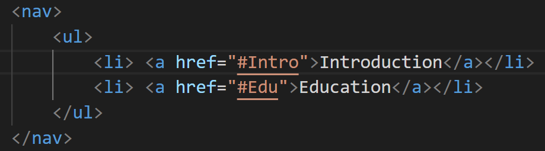

2. Connect to section
- Add id in the element, e.g, `<p id = >`

### 13. Div element

`<div>` is used to group sections of a web page together

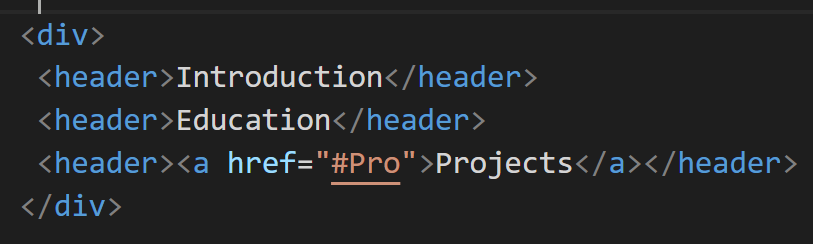

We can have many `<div>` elements on the same page

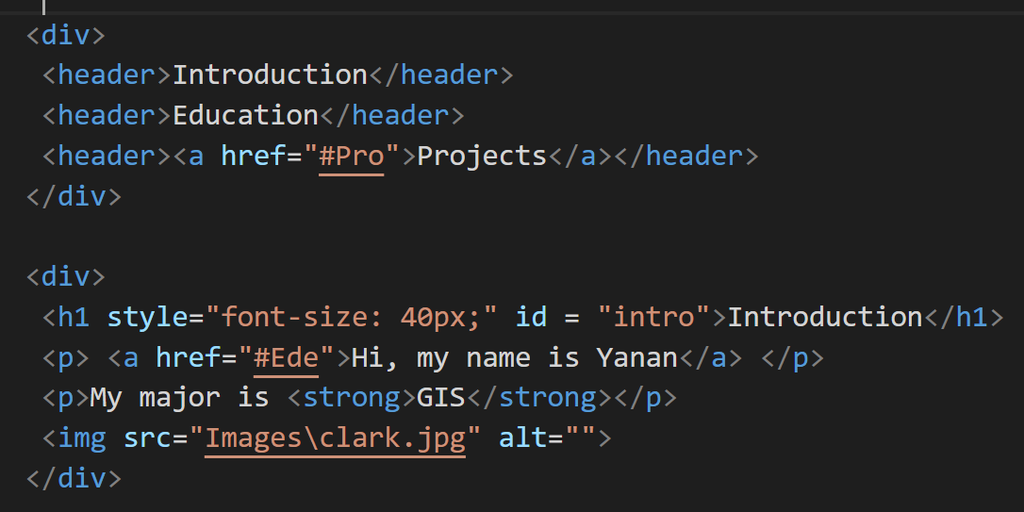

### Exercise 7: Add Div

1. Use the `<div>` to group sections of a web page together

### Exercise 8. Div contain figure and figure caption

1. Learn how many `<div>` need to be used for group sections
2. Use a `<figure>` element to mark up a photo in a document, and a `<figcaption>` element to define a caption for the photo

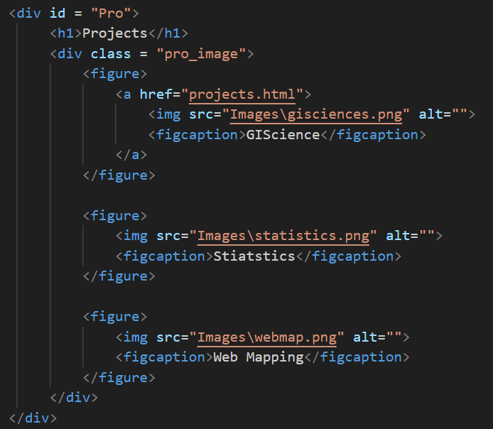

### 13. footer tag

- Defines a footer for a document or section

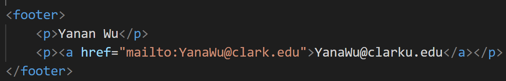

### Exercise 9: Add footer

1. Add footer

[Comprehend list of HTML Tags](https://www.w3schools.com/tags/default.asp)

### Troubleshooting

If you get error message like below:

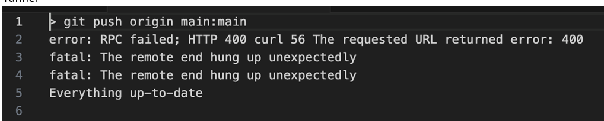

The possible issue is the buffer size in GitHub

Solution:

`git config http.postBuffer 524288000`

Or decrease the image's size on your personal website

2025-02-22 2025-02-22